# The methylCC user’s guide

Stephanie C. Hicks (shicks@jimmy.harvard.edu) and Rafael Irizarry (rafa@jimmy.harvard.edu)

July 26, 2017

# 1 Introduction

There are several approaches available to adjust for differents in the relative proportion of cell types in whole blood measured from DNA methylation (DNAm). For example, *reference-based approaches* require the use of reference data sets made up of purified cell types to identify cell-type specific DNAm signatures. These cell-type specific DNAm signatures are used to estimate the relative proportions of cell types directly, but these reference data sets are laborious and expensive to collect. Furthermore, these reference data sets will need to be continuously collected over time as new platform technologies emerge measuring DNAm because the observed methylation levels for the same CpGs in the same sample vary depending the platform technology.

In contrast, there are *reference-free approaches*, which are based on methods related to surrogate variable analysis or linear mixed models. These approaches do not provide estimates of the relative proportions of cell types, but rather these methods just remove the variability induced from the differences in relative cell type proportions in whole blood samples.

Here we present a statistical model that estimates the cell composition of whole blood samples measured from DNAm. The method can be applied to microarray or sequencing data (for example whole-genome bisulfite sequencing data, WGBS, reduced representation bisulfite sequencing data, RRBS). Our method is based on the idea of identifying informative genomic regions that are clearly methylated or unmethylated for each cell type, which permits estimation in multiple platform technologies as cell types preserve their methylation state in regions independent of platform despite observed measurements being platform dependent.

# 2 Getting Started

Load the `methylCC` R package and other packages that we’ll need later on.

```r
library(methylCC)
library(minfi)
library(tidyr)
library(ggplot2)
```

# 3 Data

## 3.1 Whole Blood Illumina 450k Microarray Data Example

```r
suppressMessages(library(FlowSorted.Blood.450k))
data(FlowSorted.Blood.450k)

# Phenotypic information about samples
head(pData(FlowSorted.Blood.450k))
```

```
## DataFrame with 6 rows and 8 columns
##          Sample_Name      Slide       Array               Basename
##          <character>  <numeric> <character>            <character>
## WB_105        WB_105 5684819001      R01C01 idat/5684819001_R01C01
## WB_218        WB_218 5684819001      R02C01 idat/5684819001_R02C01
## WB_261        WB_261 5684819001      R03C01 idat/5684819001_R03C01
## PBMC_105    PBMC_105 5684819001      R04C01 idat/5684819001_R04C01
## PBMC_218    PBMC_218 5684819001      R05C01 idat/5684819001_R05C01
## PBMC_261    PBMC_261 5684819001      R06C01 idat/5684819001_R06C01
##             SampleID CellTypeLong    CellType         Sex
##          <character>  <character> <character> <character>
## WB_105           105  Whole blood         WBC           M
## WB_218           218  Whole blood         WBC           M
## WB_261           261  Whole blood         WBC           M
## PBMC_105         105         PBMC        PBMC           M
## PBMC_218         218         PBMC        PBMC           M
## PBMC_261         261         PBMC        PBMC           M
```

```r
# RGChannelSet
rgset <- FlowSorted.Blood.450k[,
                pData(FlowSorted.Blood.450k)$CellTypeLong %in% "Whole blood"]
```

# 4 Using the `estimateCC()` function

## 4.1 Input for `estimateCC()`

The `estimateCC()` function must have one object as input:

1. an `object` such as an `RGChannelSet` from the R package `minfi` or a `BSseq` object from the R package `bsseq`.

## 4.2 Running `estimateCC()`

In this example, we are interested in estimating the cell composition of the whole blood samples listed in the `FlowSorted.Blood.450k` R/Bioconductor package. To run the `methylcC::estimateCC()` function, just provide the `RGChannelSet`. This will create an `estimateCC` object. We will call the object `est`.

```r
est <- estimateCC(object = rgset, verbose = FALSE)
est
```

```
## estimateCC: Estimate Cell Composition of Whole Blood Samples using DNA methylation
##    Input object class:  RGChannelSet
##    Reference cell types:  Tcell Bcell Mono Gran
##    Number of Whole Blood Samples:  6
```

To see the cell composition estimates, use the `cellcounts()` function. To see summary information about the object, use the `summary()` function.

```r
cellcounts(est)
```

```
##            Tcell       Bcell       Mono      Gran
## WB_105 0.4076755 0.016580639 0.10092184 0.4748221
## WB_218 0.2675142 0.032467318 0.16725824 0.5327602
## WB_261 0.2847367 0.005872798 0.11640331 0.5929872
## WB_043 0.2802753 0.058452727 0.10540909 0.5558629
## WB_160 0.1573983 0.000000000 0.12256896 0.7200327
## WB_149 0.2901391 0.030712223 0.09801077 0.5811379
```

```r
summary(est)
```

```
## $class
## [1] "RGChannelSet"
## attr(,"package")
## [1] "minfi"
##
## $nSamples
## [1] 6
##
## $cellTypes
## [1] "Tcell" "Bcell" "Mono"  "Gran"
##
## $sampleNames
## [1] "WB_105" "WB_218" "WB_261" "WB_043" "WB_160" "WB_149"
##
## $initParamMethod
## [1] "random"
##
## $nRegions
## [1] 212
```

## 4.3 Compare to `minfi::estimateCellCounts()`

We can also use the `estimateCellCounts()` from R/Bioconductor package [`minfi`](http://bioconductor.org/packages/release/bioc/html/minfi.html) to estimate the cell composition for each of the whole blood samples.

```r
sampleNames(rgset) <- paste0("Sample", 1:6)

countsMinfi <- minfi::estimateCellCounts(rgset)
```

```
## [estimateCellCounts] Combining user data with reference (flow sorted) data.
```

```
## [estimateCellCounts] Processing user and reference data together.
```

```
## [preprocessQuantile] Mapping to genome.
```

```
## [preprocessQuantile] Fixing outliers.
```

```
## [preprocessQuantile] Quantile normalizing.
```

```
## [estimateCellCounts] Picking probes for composition estimation.
```

```
## [estimateCellCounts] Estimating composition.
```

```r
data.frame("Tcell" = rowSums(countsMinfi[,1:3]), countsMinfi[,c(4,5,6)])
```

```
##             Tcell      Bcell       Mono      Gran
## Sample1 0.4353874 0.07040633 0.06383445 0.4835306
## Sample2 0.3058171 0.09859270 0.12429751 0.5228217
## Sample3 0.3036560 0.05447982 0.06775822 0.6064806
## Sample4 0.2996857 0.11447040 0.05233509 0.5700027
## Sample5 0.1883512 0.04767462 0.07452445 0.7069746
## Sample6 0.3073677 0.07039283 0.05196749 0.5932074
```

Then, we can compare the estimates to `methylcC::estimateCC()`.

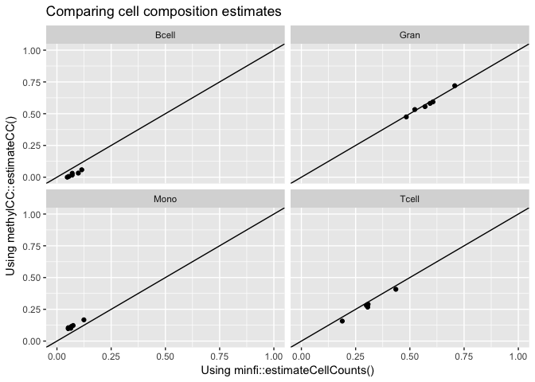

```r
df1 = gather(cbind("samples" = summary(est)$sampleNames,
                   data.frame("Tcell" = rowSums(countsMinfi[,1:3]), countsMinfi[,c(4,5,6)])),
             celltype, est, -samples)

df2 = gather(cbind("samples" = summary(est)$sampleNames, cellcounts(est)),
             celltype, est, -samples)

dfcombined <- dplyr::full_join(df1, df2, by = c("samples", "celltype"))

ggplot(dfcombined, aes(x=est.x, y = est.y)) +
    geom_abline(intercept = 0, slope = 1) + xlim(0,1) + ylim(0,1) +
    facet_wrap(~celltype) + geom_point() +
    xlab("Using minfi::estimateCellCounts()") + ylab("Using methylCC::estimateCC()") +
    labs(title = "Comparing cell composition estimates")
```